# Grand River microbiome Analysis 2022 - Creating phyloseq objects

Milena Esser

29/04/2025

1. This script creates a phyloseq object from three input files:
- feature_table.tsv
- taxonomy_table.tsv
- metadata.tsv
2. After *creating the phyloseq object*, there is a filtering step to remove contaminated samples, controls, as well as Chloroplasts and Mitochondria.
3. The script includes multiple options to *normalize for varying sequencing depth* (e.g., rarefaction, proportional normalization, CSS) for ecological metrics analysis (e.g., alpha/beta diversity0
4. Lastly, the resulting *phyloseq objects are saved for use in downstream analyses* such as diversity assessment and differential abundance. *(**IMPORTANT**: This includes normalized ps files, as well as the unnormalized ps, as some downstream analysis have their own normalization/transformation methods, e.g., DeSeq2 for differential abundance analysis using variance stabilizing transformation (VST), which normalizes for varying sequencing depth and dispersion*)

## 1 **Create and Filter Phyloseq object**

Make sure your ASV table has a column for ASV IDs and the rest are sample counts.

The taxonomy table should have ASV IDs in the first column and taxonomy as separate columns or a single concatenated string (e.g., `"Kingdom;Phylum;Class;..."`).

```
## PS object:
```

```
## phyloseq-class experiment-level object
## otu_table()   OTU Table:         [ 39764 taxa and 384 samples ]
## sample_data() Sample Data:       [ 384 samples by 14 sample variables ]
## tax_table()   Taxonomy Table:    [ 39764 taxa by 7 taxonomic ranks ]
## refseq()      DNAStringSet:      [ 39764 reference sequences ]
```

### 1.1 Filtering

So far, the data includes multiple data sets from different studies. So I first filter out the Grand River data.

Filter out potentially contaminated samples:

- KK2580 (WAT_DWN3_Ad_Mayfly_MB_3) appeared as outlier during beta diversity analysis as it had an MDS1 of >4000. Remove from dataset:

```
## Outlier sample WAT_DWN3_Ad_Mayfly_MB_3 successfully removed.
```

```
## PS object all experimental samples:
```

```
## phyloseq-class experiment-level object
## otu_table()   OTU Table:         [ 39764 taxa and 383 samples ]
## sample_data() Sample Data:       [ 383 samples by 14 sample variables ]
## tax_table()   Taxonomy Table:    [ 39764 taxa by 7 taxonomic ranks ]
## refseq()      DNAStringSet:      [ 39764 reference sequences ]
```

To look at blanks individually, I will create a separate ps file

The following does:

1. **Subset to experimental samples**  
   Removes any samples where `Lifestage` is `NA`, likely excluding blanks or non-target samples.
2. **Keep only prokaryotes (Bacteria and Archaea)**  
   Filters out all non-prokaryotic sequences such as Eukaryotes and unclassified domains. The code also tracks how many ASVs were removed and how many were Archaea.
3. **Remove organelle-derived sequences**  
   Filters out ASVs assigned to chloroplasts or mitochondria, which are common contaminants from host or plant material in 16S datasets.
4. **Remove rare ASVs**  
   Uses `ps_prune()` to exclude ASVs that have fewer than 5 reads and are present in fewer than 2 samples.
5. **Remove low-read samples**  
   Filters out any samples with fewer than 1000 total reads, ensuring sufficient sequencing depth.
6. **Keep only ASVs present with >10 reads in at least one sample**  
   Focuses the analysis on more confidently observed taxa.
7. **Remove poorly classified ASVs at the Phylum level**  
   Excludes any taxa that lack a clear phylum-level classification or are ambiguously labeled (e.g., `"uncharacterized"` or `"NA"`).

```
## ASVs removed (non-Bacteria/Archaea): 7
```

```
## Archaea-only ASVs: 0
```

```
## ASVs removed (Chloroplasts/Mitochondria): 1344
```

```
## Final PS object after filtering:
```

```
## phyloseq-class experiment-level object
## otu_table()   OTU Table:         [ 10417 taxa and 359 samples ]
## sample_data() Sample Data:       [ 359 samples by 14 sample variables ]
## tax_table()   Taxonomy Table:    [ 10417 taxa by 7 taxonomic ranks ]
```

```
## Original number of samples: 375
```

```
## Number of samples remaining after filtering: 359
```

## 2 **Investigating Sequencing Depth**

### 2.1 Rarefaction curve

```
## Minimum sequencing depth: 1077
```

```
## Maximum sequencing depth: 449398
```

```
## Total reads across all samples: 21471889
```

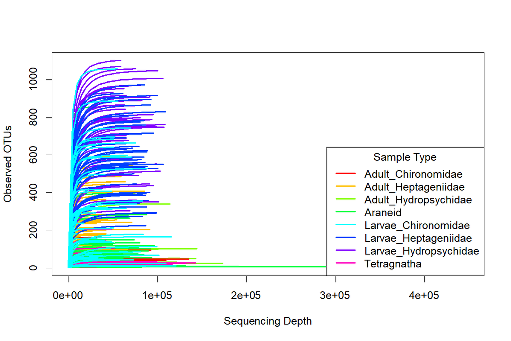

### 2.2 Goods coverage estimate

= 1-(F1/N)

F1= number of singletons (reads that only occur once)

N=number of reads per sample

**Rule of thumb:** Values >95% are generally considered good coverage

If your samples show lower coverage, especially inconsistently across groups, this can bias diversity estimates.

```
## Good's Coverage Summary:
```

```
##    Min. 1st Qu.  Median    Mean 3rd Qu.    Max.
##  0.9997  1.0000  1.0000  1.0000  1.0000  1.0000
```

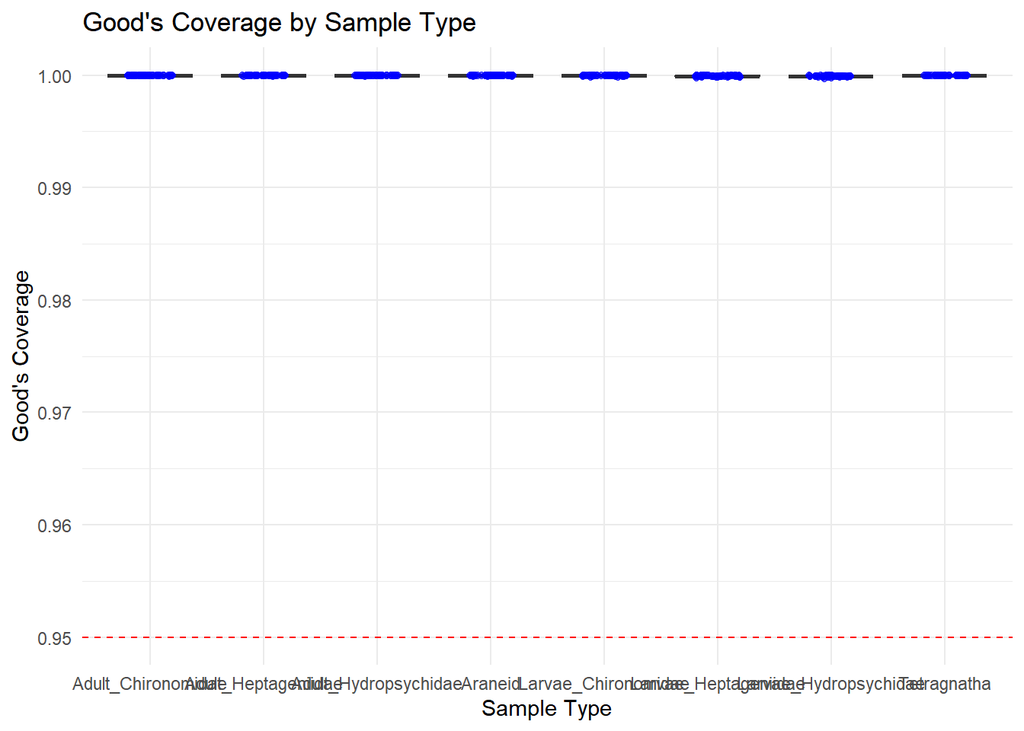

## 3 **Normalization**

Normalization is currently a much-discussed issue of microbiome studies. Differences in read depth between samples often need to be corrected before analysis. Several normalization methods have been proposed, and no single method is perfect. It may be that the most appropriate method depends on the analysis.

### 3.1 Rarefaction

**IMPORTANT**: *the normalization level selected here has been identified based on the data itself (keeping it as high as possible without losing too many samples due to low sequencing depth). Therefore, this needs to be adjusted in case of differing data.*

*Also: The diversity differs significantly between some of the taxonomic groups sampled (e.g., spiders have generally very low diversity). It may be better to rarefy them separately, but this would not allow for comparison between taxonomic groups!.*

```
## The selected rarefaction level is: 2247  reads
```

```
## rarefied PS object (ps_rare):
```

```
## phyloseq-class experiment-level object
## otu_table()   OTU Table:         [ 9441 taxa and 353 samples ]
## sample_data() Sample Data:       [ 353 samples by 14 sample variables ]
## tax_table()   Taxonomy Table:    [ 9441 taxa by 7 taxonomic ranks ]
```

```
## Number of samples left per sample type and site after rarefaction:
```

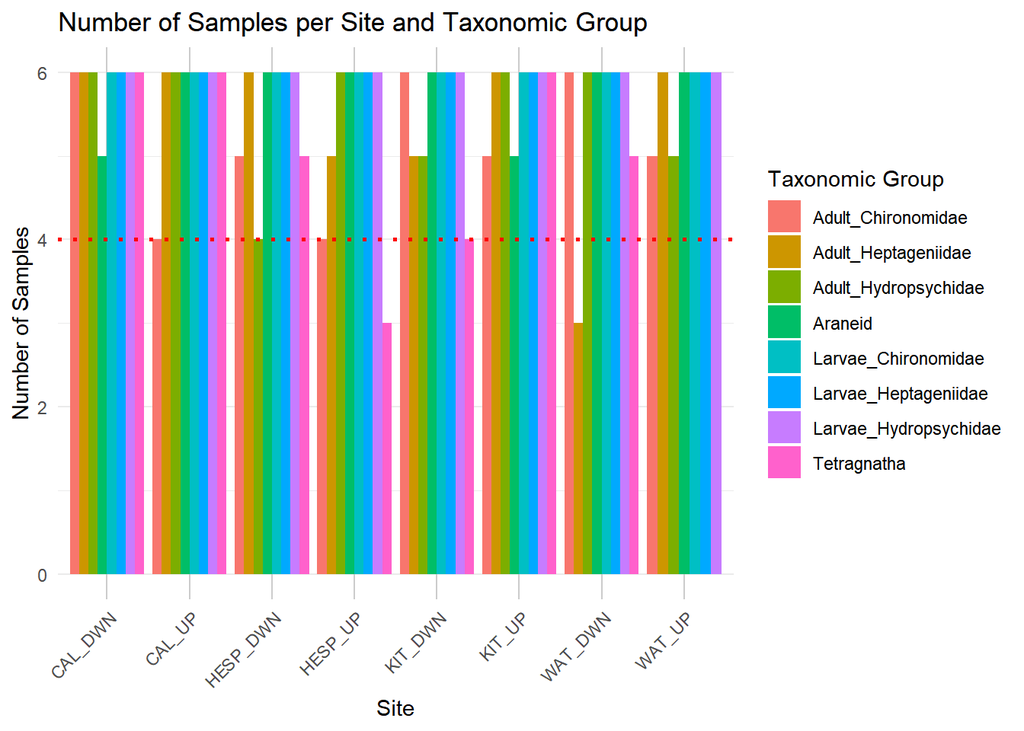

### 3.2 Proportion normalization

Proportion normalization involves dividing each OTU count by the total sum for each sample. The resulting count data will add up to 1 (100%) for each sample.

```
## OTU Table:          [5 taxa and 5 samples]
##                      taxa are rows
##            KK2487 KK2488    KK2489     KK2490 KK2491
## ASV1 0.0001383738      0 0.0000000 0.60039553      0
## ASV2 0.0000000000      0 0.0000000 0.00000000      0
## ASV3 0.0000000000      0 0.5451834 0.08032619      0
## ASV4 0.0000000000      0 0.0000000 0.00000000      0
## ASV5 0.0000000000      0 0.0000000 0.00000000      0
```

```
## KK2487 KK2488 KK2489 KK2490 KK2491 KK2492
##      1      1      1      1      1      1
```

### 3.3 Cumulative Sum Scaling (CSS)

The *metagenomeSeq* Cumulative Sum Scaling (CSS) normalization is another option developed for microbiome data. For more information, read [Paulson et al. 2013](http://www.nature.com/articles/nmeth.2658).

```
## OTU Table:          [5 taxa and 5 samples]
##                      taxa are columns
##               ASV1 ASV2      ASV3 ASV4 ASV5
## KK2487    0.168822    0    0.0000    0    0
## KK2488    0.000000    0    0.0000    0    0
## KK2489    0.000000    0 1198.6885    0    0
## KK2490 1880.477174    0  251.5868    0    0
## KK2491    0.000000    0    0.0000    0    0
```

## 4 **Save phyloseq object for easy reloading**

**Saved phyloseq objects:**

- *ps_final* (Unrarefied, filtered): `GrandRiverMB_phyloseq_filt_unnorm.RData`
- *ps_rare* (Rarefied to even sequencing depth): `GrandRiverMB_phyloseq_filt_rar.RData`
- *ps_prop* (Proportion-normalized to relative abundance): `GrandRiverMB_phyloseq_filt_propnorm.RData`
- *ps_css* (CSS-normalized for compositionality and sequencing depth): `GrandRiverMB_phyloseq_filt_css.RData`